# Practical Machine Learning Course Project

Chia

December 25, 2015

## Background

Machine Learning is the process of using algorithms to learn from data. One thing that people regularly do is quantify how much of a particular activity they do, but they rarely quantify how well they do it. In this project, your goal will be to use data from accelerometers on the belt, forearm, arm, and dumbell of 6 participants. They were asked to perform barbell lifts correctly and incorrectly in 5 different ways. More information is available from the website here: http://groupware.les.inf.puc-rio.br/har (see the section on the Weight Lifting Exercise Dataset).

The goal of this project is to predict the manner of performing unilateral dumbbell biceps curls based on data from accelerometers on the belt, forearm, arm, and dumbell of 6 participants. The 5 possible Class include -

A: exactly according to the specification  
B: throwing the elbows to the front  
C: lifting the dumbbell only halfway  
D: lowering the dumbbell only halfway  
E: throwing the hips to the front

Class A corresponds to the specified execution of the exercise, while the other 4 classes correspond to common mistakes.

### Data

The training data for this project are available here: https://d396qusza40orc.cloudfront.net/predmachlearn/pml-training.csv

The test data are available here: https://d396qusza40orc.cloudfront.net/predmachlearn/pml-testing.csv

The data for this project come from this source: http://groupware.les.inf.puc-rio.br/har.

### Goal

The goal of your project is to predict the manner in which they did the exercise. This is the “classe” variable in the training set. You may use any of the other variables to predict with. You should create a report describing how you built your model, how you used cross validation, what you think the expected out of sample error is, and why you made the choices you did. You will also use your prediction model to predict 20 different test cases.

## Load the libraries and setup working environment

```r
rm(list = ls(all = TRUE))
set.seed(12345)
library(caret)
library(rattle)       # for Decision Tree
```

```r
library(rpart.plot)   # for Decision Tree
library(parallel)
library(doParallel)
```

## Getting and loading the data

```r
if (!file.exists("./Module8_Week3/pml-training.csv")){
    download.file("https://d396qusza40orc.cloudfront.net/predmachlearn/pml-training.csv",
                  "./Module8_Week3/pml-training.csv")
}
if (!file.exists("./Module8_Week3/pml-testing.csv")){
    download.file("https://d396qusza40orc.cloudfront.net/predmachlearn/pml-testing.csv",
                  "./Module8_Week3/pml-testing.csv")
}
rawData = read.csv("./Module8_Week3/pml-training.csv", na.strings = c("NA", ""))
rawData$classe <- as.factor(rawData$classe)
dim(rawData)
```

```
## [1] 19622   160
```

```r
summary(rawData$classe)
```

```
##    A    B    C    D    E
## 5580 3797 3422 3216 3607
```

The raw dataset contained 19622 rows of data, with 160 variables. We will be predicting on classe outcome variable and the data is split up between the five classes i.e. A, B, C, D, E.

## Process the data

### Clean the data

Many variables contained missing data, so these are to be removed from the dataset. In addition, those variables not related to movement sensors were also to be removed and resulted in a dataset with 53 variables.  
Belt, arm, dumbbell, and forearm variables that do not have any missing values in the raw dataset will be predictor variables.

```r
isAnyNA <- sapply(rawData, function (x) any(is.na(x) | x == ""))
isPredictor <- !isAnyNA & grepl("belt|[^(fore)]arm|dumbbell|forearm", names(isAnyNA))
predictVar <- names(isAnyNA)[isPredictor]
predictVar
```

```
##  [1] "roll_belt"            "pitch_belt"           "yaw_belt"
##  [4] "total_accel_belt"     "gyros_belt_x"         "gyros_belt_y"
##  [7] "gyros_belt_z"         "accel_belt_x"         "accel_belt_y"
## [10] "accel_belt_z"         "magnet_belt_x"        "magnet_belt_y"
## [13] "magnet_belt_z"        "roll_arm"             "pitch_arm"
## [16] "yaw_arm"              "total_accel_arm"      "gyros_arm_x"
## [19] "gyros_arm_y"          "gyros_arm_z"          "accel_arm_x"
## [22] "accel_arm_y"          "accel_arm_z"          "magnet_arm_x"
## [25] "magnet_arm_y"         "magnet_arm_z"         "roll_dumbbell"
## [28] "pitch_dumbbell"       "yaw_dumbbell"         "total_accel_dumbbell"
## [31] "gyros_dumbbell_x"     "gyros_dumbbell_y"     "gyros_dumbbell_z"
## [34] "accel_dumbbell_x"     "accel_dumbbell_y"     "accel_dumbbell_z"
## [37] "magnet_dumbbell_x"    "magnet_dumbbell_y"    "magnet_dumbbell_z"
## [40] "roll_forearm"         "pitch_forearm"        "yaw_forearm"
## [43] "total_accel_forearm"  "gyros_forearm_x"      "gyros_forearm_y"
## [46] "gyros_forearm_z"      "accel_forearm_x"      "accel_forearm_y"
## [49] "accel_forearm_z"      "magnet_forearm_x"     "magnet_forearm_y"
## [52] "magnet_forearm_z"
```

Subset the raw dataset to include only the predictor variables and the classe outcome variable.

```r
allVariables <- c("classe", predictVar)
rawData <- rawData[, allVariables]
dim(rawData)
```

```
## [1] 19622    53
```

```r
names(rawData)
```

```
##  [1] "classe"               "roll_belt"            "pitch_belt"
##  [4] "yaw_belt"             "total_accel_belt"     "gyros_belt_x"
##  [7] "gyros_belt_y"         "gyros_belt_z"         "accel_belt_x"
## [10] "accel_belt_y"         "accel_belt_z"         "magnet_belt_x"
## [13] "magnet_belt_y"        "magnet_belt_z"        "roll_arm"
## [16] "pitch_arm"            "yaw_arm"              "total_accel_arm"
## [19] "gyros_arm_x"          "gyros_arm_y"          "gyros_arm_z"
## [22] "accel_arm_x"          "accel_arm_y"          "accel_arm_z"
## [25] "magnet_arm_x"         "magnet_arm_y"         "magnet_arm_z"
## [28] "roll_dumbbell"        "pitch_dumbbell"       "yaw_dumbbell"
## [31] "total_accel_dumbbell" "gyros_dumbbell_x"     "gyros_dumbbell_y"
## [34] "gyros_dumbbell_z"     "accel_dumbbell_x"     "accel_dumbbell_y"
## [37] "accel_dumbbell_z"     "magnet_dumbbell_x"    "magnet_dumbbell_y"
## [40] "magnet_dumbbell_z"    "roll_forearm"         "pitch_forearm"
## [43] "yaw_forearm"          "total_accel_forearm"  "gyros_forearm_x"
## [46] "gyros_forearm_y"      "gyros_forearm_z"      "accel_forearm_x"
## [49] "accel_forearm_y"      "accel_forearm_z"      "magnet_forearm_x"
## [52] "magnet_forearm_y"     "magnet_forearm_z"
```

### Split the data

Split the raw dataset into a 60% training and 40% test dataset.

```r
inTrain = createDataPartition(y=rawData$classe, p=0.6, list=FALSE)
trainData = rawData[inTrain, ]
testData = rawData[-inTrain, ]
dim(trainData)
```

```
## [1] 11776    53
```

### Preprocess the predictor variables by centering and scaling.

```r
preObj <- preProcess(trainData[, predictVar], method=c("center", "scale"))
preObj
```

```
## Created from 11776 samples and 52 variables
##
## Pre-processing:
##   - centered (52)
##   - ignored (0)
##   - scaled (52)
```

```r
predTemp <- predict(preObj, trainData[, predictVar])
trainDataCS <- data.frame(classe = trainData$classe, predTemp)
```

Apply the centering and scaling to the test dataset.

```r
predTemp <- predict(preObj, testData[, predictVar])
testDataCS <- data.frame(classe = testData$classe, predTemp)
```

## Build the prediction models and compare it

We will create two models to compare the accuracy of predicting the classe outcome variable on the remaining predictor variables by using the confusionMatrix.

### Prediction with Decision Tree

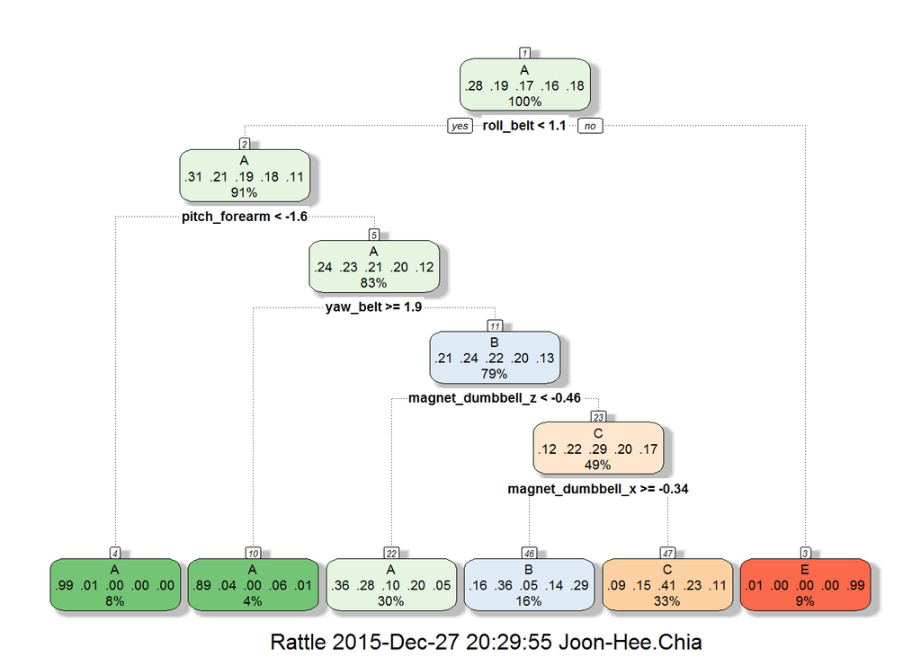

```r
trainModel <- train(classe ~ ., method = "rpart", data = trainDataCS)
fancyRpartPlot(trainModel$finalModel)
```

### Evaluate the Decision Tree on the test dataset

```r
prediction <- predict(trainModel, testDataCS)
confusionMatrix(prediction, testData$classe)
```

```
## Confusion Matrix and Statistics
##
##           Reference
## Prediction    A    B    C    D    E
##          A 1765  701  267  508  136
##          B  219  444   62  157  372
##          C  240  373 1039  621  299
##          D    0    0    0    0    0
##          E    8    0    0    0  635
##
## Overall Statistics
##
##                Accuracy : 0.4949
##                  95% CI : (0.4838, 0.506)
##     No Information Rate : 0.2845
##     P-Value [Acc > NIR] : < 2.2e-16
##
##                   Kappa : 0.3478
##  Mcnemar's Test P-Value : NA
##
## Statistics by Class:
##
##                      Class: A Class: B Class: C Class: D Class: E
## Sensitivity            0.7908  0.29249   0.7595   0.0000  0.44036
## Specificity            0.7129  0.87200   0.7634   1.0000  0.99875
## Pos Pred Value         0.5227  0.35407   0.4040      NaN  0.98756
## Neg Pred Value         0.8955  0.83708   0.9376   0.8361  0.88796
## Prevalence             0.2845  0.19347   0.1744   0.1639  0.18379
## Detection Rate         0.2250  0.05659   0.1324   0.0000  0.08093
## Detection Prevalence   0.4304  0.15983   0.3278   0.0000  0.08195
## Balanced Accuracy      0.7518  0.58224   0.7614   0.5000  0.71956
```

### Prediction with Random Forest

```r
cl <- makeCluster(detectCores() - 1)
registerDoParallel(cl)
ctrl <- trainControl(classProbs = TRUE, savePredictions = TRUE, allowParallel = TRUE)
system.time(trainModel <- train(classe ~ ., method = "rf", data = trainDataCS))
```

```
##    user  system elapsed
##   61.53    1.46 2417.73
```

```r
stopCluster(cl)
trainModel
```

```
## Random Forest
##
## 11776 samples
##    52 predictor
##     5 classes: 'A', 'B', 'C', 'D', 'E'
##
## No pre-processing
## Resampling: Bootstrapped (25 reps)
## Summary of sample sizes: 11776, 11776, 11776, 11776, 11776, 11776, ...
## Resampling results across tuning parameters:
##
##   mtry  Accuracy   Kappa      Accuracy SD  Kappa SD
##    2    0.9863837  0.9827778  0.002439885  0.003085431
##   27    0.9865419  0.9829794  0.002316254  0.002926421
##   52    0.9778425  0.9719799  0.005141571  0.006490046
##
## Accuracy was used to select the optimal model using  the largest value.
## The final value used for the model was mtry = 27.
```

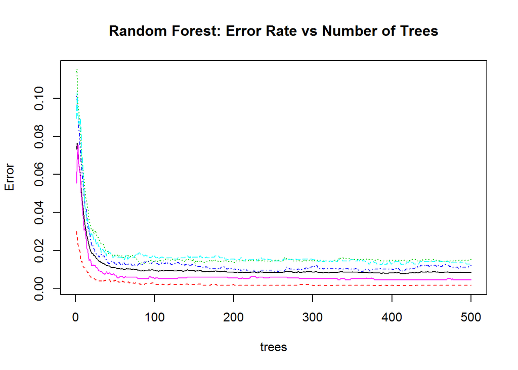

```r
save(trainModel, file="trainModel.RData")
plot(trainModel$finalModel, main="Random Forest: Error Rate vs Number of Trees")
```

### Evaluate the Random Fores model on the train dataset

```r
prediction <- predict(trainModel, trainDataCS)
confusionMatrix(prediction, trainData$classe)
```

```
## Confusion Matrix and Statistics
##
##           Reference
## Prediction    A    B    C    D    E
##          A 3348    0    0    0    0
##          B    0 2279    0    0    0
##          C    0    0 2054    0    0
##          D    0    0    0 1930    0
##          E    0    0    0    0 2165
##
## Overall Statistics
##
##                Accuracy : 1
##                  95% CI : (0.9997, 1)
##     No Information Rate : 0.2843
##     P-Value [Acc > NIR] : < 2.2e-16
##
##                   Kappa : 1
##  Mcnemar's Test P-Value : NA
##
## Statistics by Class:
##
##                      Class: A Class: B Class: C Class: D Class: E
## Sensitivity            1.0000   1.0000   1.0000   1.0000   1.0000
## Specificity            1.0000   1.0000   1.0000   1.0000   1.0000
## Pos Pred Value         1.0000   1.0000   1.0000   1.0000   1.0000
## Neg Pred Value         1.0000   1.0000   1.0000   1.0000   1.0000
## Prevalence             0.2843   0.1935   0.1744   0.1639   0.1838
## Detection Rate         0.2843   0.1935   0.1744   0.1639   0.1838
## Detection Prevalence   0.2843   0.1935   0.1744   0.1639   0.1838
## Balanced Accuracy      1.0000   1.0000   1.0000   1.0000   1.0000
```

### Evaluate the Random Forest model on the test dataset

```r
prediction <- predict(trainModel, testDataCS)
cmrf <- confusionMatrix(prediction, testData$classe)
cmrf
```

```
## Confusion Matrix and Statistics
##
##           Reference
## Prediction    A    B    C    D    E
##          A 2228   11    0    0    0
##          B    3 1497    5    0    3
##          C    0   10 1361   20    4
##          D    0    0    2 1263    4
##          E    1    0    0    3 1431
##
## Overall Statistics
##
##                Accuracy : 0.9916
##                  95% CI : (0.9893, 0.9935)
##     No Information Rate : 0.2845
##     P-Value [Acc > NIR] : < 2.2e-16
##
##                   Kappa : 0.9894
##  Mcnemar's Test P-Value : NA
##
## Statistics by Class:
##
##                      Class: A Class: B Class: C Class: D Class: E
## Sensitivity            0.9982   0.9862   0.9949   0.9821   0.9924
## Specificity            0.9980   0.9983   0.9948   0.9991   0.9994
## Pos Pred Value         0.9951   0.9927   0.9756   0.9953   0.9972
## Neg Pred Value         0.9993   0.9967   0.9989   0.9965   0.9983
## Prevalence             0.2845   0.1935   0.1744   0.1639   0.1838
## Detection Rate         0.2840   0.1908   0.1735   0.1610   0.1824
## Detection Prevalence   0.2854   0.1922   0.1778   0.1617   0.1829
## Balanced Accuracy      0.9981   0.9922   0.9948   0.9906   0.9959
```

Random Forest gives an accuracy on the Test dataset of 99.16%, which is more accurate than Decision Tree.

The Out of sample error is 0.84%.

### Show the final model

```r
varImp(trainModel)
```

```
## rf variable importance
##
##   only 20 most important variables shown (out of 52)
##
##                      Overall
## roll_belt             100.00
## pitch_forearm          58.63
## yaw_belt               55.54
## pitch_belt             43.67
## magnet_dumbbell_z      43.51
## magnet_dumbbell_y      40.16
## roll_forearm           38.13
## accel_dumbbell_y       20.52
## roll_dumbbell          19.47
## magnet_dumbbell_x      18.49
## accel_forearm_x        16.76
## accel_dumbbell_z       15.43
## magnet_belt_z          15.41
## total_accel_dumbbell   13.84
## magnet_belt_y          13.11
## accel_belt_z           13.06
## gyros_belt_z           11.82
## magnet_belt_x          11.71
## magnet_forearm_z       11.58
## yaw_arm                10.97
```

```r
trainModel$finalModel
```

```
##
## Call:
##  randomForest(x = x, y = y, mtry = param$mtry)
##                Type of random forest: classification
##                      Number of trees: 500
## No. of variables tried at each split: 27
##
##         OOB estimate of  error rate: 0.86%
## Confusion matrix:
##      A    B    C    D    E class.error
## A 3342    5    1    0    0 0.001792115
## B   25 2244   10    0    0 0.015357613
## C    0   15 2029   10    0 0.012171373
## D    0    0   24 1905    1 0.012953368
## E    0    0    4    6 2155 0.004618938
```

## Read the model and predict 20 different test cases for submission.

```r
load(file="trainModel.RData", verbose=TRUE)
```

```
## Loading objects:
##   trainModel
```

```r
testCase = read.csv("./Module8_Week3/pml-testing.csv", na.strings = c("NA", ""))
testCaseCS <- predict(preObj, testCase[, predictVar])
prediction <- predict(trainModel, testCaseCS)
prediction
```

```
##  [1] B A B A A E D B A A B C B A E E A B B B
## Levels: A B C D E
```

```r
pml_write_files = function(x){
    n = length(x)
    for(i in 1:n){
        filename = paste0("problem_id_", i, ".txt")
        write.table(x[i], file=filename, quote=FALSE, row.names=FALSE, col.names=FALSE)
    }
}
pml_write_files(prediction)
```